# Multi-species Occupancy Models

# Breaking the model

```r
summary(fit_4)
```

```
##
## Call:
## occuMulti(detformulas = c("~temp", "~temp", "~temp"), stateformulas = c("~Dist_5km",
##     "~HDens_5km", "~People_site", "~Latitude + Longitude", "~Latitude + Longitude",
##     "~Latitude + Longitude"), data = msom_data, maxOrder = 2,
##     control = list(maxit = 1000))
```

```
## Occupancy (logit-scale):
##                              Estimate       SE      z  P(>|z|)
## [bobcat] (Intercept)        -1.70e+00  0.26073 -6.526 6.73e-11
## [bobcat] Dist_5km           -2.98e+01  6.04181 -4.939 7.86e-07
## [coyote] (Intercept)        -1.16e+00  0.14608 -7.969 1.60e-15
## [coyote] HDens_5km          -2.02e-03  0.00248 -0.814 4.16e-01
## [redfox] (Intercept)        -3.25e+01      NaN    NaN      NaN
## [redfox] People_site         2.22e+00  0.40671  5.470 4.50e-08
## [bobcat:coyote] (Intercept) -5.14e+01  9.97500 -5.155 2.54e-07
## [bobcat:coyote] Latitude     3.81e+01 13.09977  2.906 3.66e-03
## [bobcat:coyote] Longitude   -4.93e+01  7.65353 -6.436 1.23e-10
## [bobcat:redfox] (Intercept) -1.15e+02 33.53803 -3.425 6.14e-04
## [bobcat:redfox] Latitude    -7.35e+01 36.23534 -2.027 4.26e-02
## [bobcat:redfox] Longitude   -1.82e+02 34.61570 -5.252 1.50e-07
## [coyote:redfox] (Intercept)  1.85e+02      NaN    NaN      NaN
## [coyote:redfox] Latitude     4.45e+01 27.74460  1.603 1.09e-01
## [coyote:redfox] Longitude    2.18e+02 31.36572  6.935 4.07e-12
##
## Detection (logit-scale):
##                      Estimate     SE       z  P(>|z|)
## [bobcat] (Intercept)  -1.2307 0.1216 -10.125 4.29e-24
## [bobcat] temp         -0.3104 0.0828  -3.748 1.78e-04
## [coyote] (Intercept)  -0.7395 0.0688 -10.753 5.71e-27
## [coyote] temp         -0.0983 0.0577  -1.704 8.84e-02
## [redfox] (Intercept)  -0.1777 0.1076  -1.652 9.86e-02
## [redfox] temp         -0.0875 0.1044  -0.838 4.02e-01
##
## AIC: 6311.065
## Number of sites: 1437
## optim convergence code: 0
## optim iterations: 273
## Bootstrap iterations: 0
```

Notice the unreasonably large coefficient estimates and standard errors.

# Penalized likelihood

- We can constrain such unreasonably large estimates by imposing a penalty on ‘large’ values of a coefficient
- Shrinks estimates toward 0
- Imposes a small bias in return for a large reduction in variance
- Will be available in next `unmarked` release. Available now via GitHub
- Details in [Clipp et al. 2021](https://doi.org/10.1002/ecy.3520)

# Penalized likelihood

- Implemented penalized likelihood via `optimizePenalty` function
- Requires a fitted model as input
- Specify a range of penalties (bigger penalties = more shrinkage)
- Uses cross-validation to identify optimal penalty, fits model the optimal penalty

```r
# this is slow to run
opt_pen <- optimizePenalty(fit_4,
                            penalties = 2 ^ seq(-5, 5),
                            boot = 100)
```

The above function will take a while to run, and the resulting object is too big to store on GitHub. You can download the .rds file here:

[Download opt_pen.rds](https://drive.google.com/u/0/uc?id=1NI_aon6hjy7xxkDqv9Rz1969aUjUOEYF&export=download)

# Penalized likelihood

Execute this code if you downloaded `opt-pen.rds`

```r
opt_pen <- readRDS('data/opt-pen.rds')
```

```r
summary(opt_pen)
```

```
##
## Call:
## occuMulti(detformulas = c("~temp", "~temp", "~temp"), stateformulas = c("~Dist_5km",
## "~HDens_5km", "~People_site", "~Latitude + Longitude", "~Latitude + Longitude",
## "~Latitude + Longitude"), data = object@data, maxOrder = 2, penalty = 0.03125,
##     boot = boot)
##
## Occupancy (logit-scale):
##                              Estimate     SE     z  P(>|z|)
## [bobcat] (Intercept)         -1.51740 0.2511 -6.04 1.52e-09
## [bobcat] Dist_5km           -14.42998 2.9613 -4.87 1.10e-06
## [coyote] (Intercept)         -1.57083 0.3716 -4.23 2.36e-05
## [coyote] HDens_5km            0.00511 0.0027  1.89 5.81e-02
## [redfox] (Intercept)         -2.86410 0.9128 -3.14 1.70e-03
## [redfox] People_site          4.16768 1.8194  2.29 2.20e-02
## [bobcat:coyote] (Intercept)  -9.78902 1.5066 -6.50 8.17e-11
## [bobcat:coyote] Latitude     -3.90075 2.9684 -1.31 1.89e-01
## [bobcat:coyote] Longitude   -16.81603 2.3686 -7.10 1.25e-12
## [bobcat:redfox] (Intercept)  -0.88576 0.5262 -1.68 9.23e-02
## [bobcat:redfox] Latitude      2.72790 1.6105  1.69 9.03e-02
## [bobcat:redfox] Longitude     2.56619 1.2868  1.99 4.61e-02
## [coyote:redfox] (Intercept)   8.44331 2.1693  3.89 9.94e-05
## [coyote:redfox] Latitude     19.98990 4.7800  4.18 2.89e-05
## [coyote:redfox] Longitude    17.28457 3.7233  4.64 3.45e-06
##
## Detection (logit-scale):
##                      Estimate     SE      z  P(>|z|)
## [bobcat] (Intercept)  -1.3558 0.1858 -7.299 2.90e-13
## [bobcat] temp         -0.3275 0.0848 -3.862 1.13e-04
## [coyote] (Intercept)  -0.4880 0.1462 -3.338 8.43e-04
## [coyote] temp         -0.0755 0.0789 -0.956 3.39e-01
## [redfox] (Intercept)  -0.3432 0.1670 -2.055 3.99e-02
## [redfox] temp          0.0853 0.1619  0.527 5.98e-01
##
## AIC: 6509.693
## Number of sites: 1437
## optim convergence code: 0
## optim iterations: 104
## Bootstrap iterations: 100
```

Notice the reasonable coefficients and standard errors.

# Continuous-time MSOM

- Recent advances allow modeling of detection in continuous time
- Permits simultaneous inference on spatial and temporal interactions
- Not yet implemented in fancy software
- [Kellner et al. *In press*](https://doi.org/10.1007/s13253-021-00482-y)

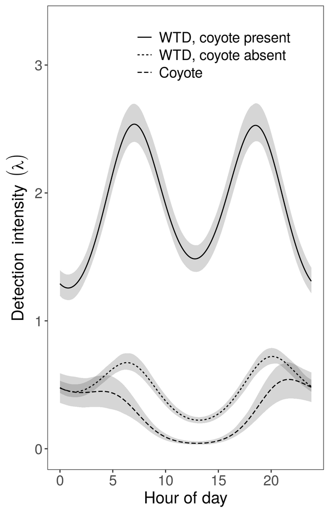

# Questions?

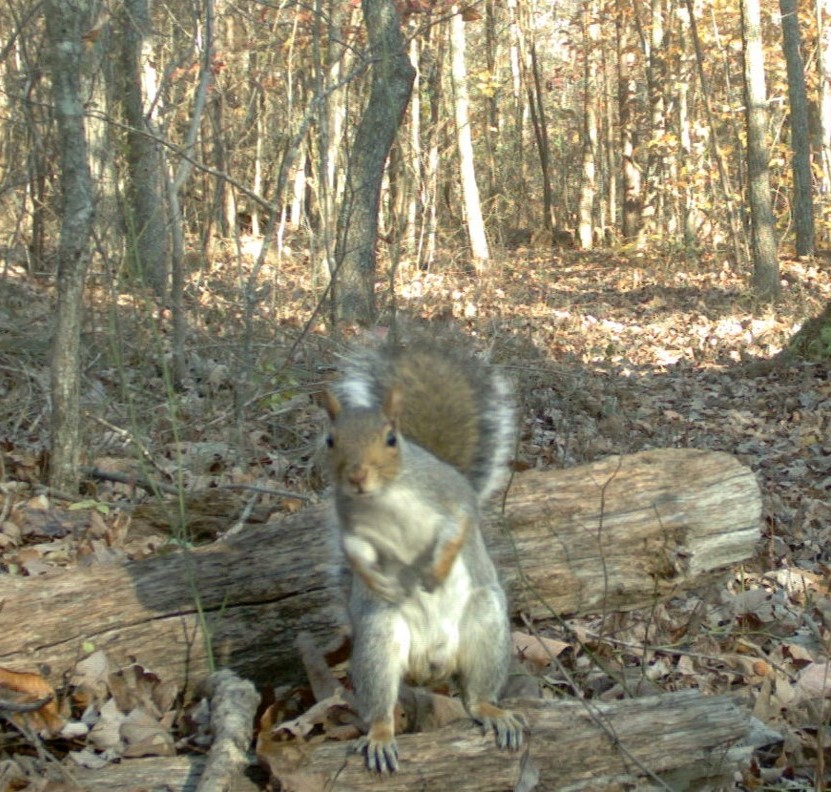